# The Influence of Twitter on the Stock Market

Rolando Franqui and Connor Brown

5/1/2020

## Introduction

In recent years, social media has become a big part of our daily lives; it affects how we communicate with others, our jobs and the economy. With social media platforms such as YouTube, Facebook, and Twitter becoming extremely popular, people are allowed to express and share information that might not be necessarily accurate or merely just an opinion; however, having such a wide reach can affect many areas significantly. The goal of our research project is to see to what extent social media (specifically twitter) has affected the behavior of traders and the economy, despite being in the midst of an economic crisis. To analyze the tweets we used sentimental analysis, we will calculate the mean sentiment of the day and compare it to the adjusted close price of the S&P 500 Index we used as our metric for market performance.

### Data collection

We first started by manually searching twitter using the built in search engine by passing in keywords that we might be able to use to gather market data. This was an extremly useful part of the process because it gave us an idea of what kind of data the queries could bring us. This process helped us eliminate queries that would add substancial noise to our data due to ads or unrelated tweets that that query gathered. We eventually settled on 8 different queries. WIth the use that we gathered using the following queries: “S&P500”, “Economy”, “SPY”,“VOO”, “Stimulus Check”, “Crude Oil”, “Stock Market”, “Recession.” From this sentiment analysis, we will calculate the mean sentiment of the day and compare it to the adjusted close price of the S&P 500 Index we used as our metric for market performance.

### Getting a Sense of the Data

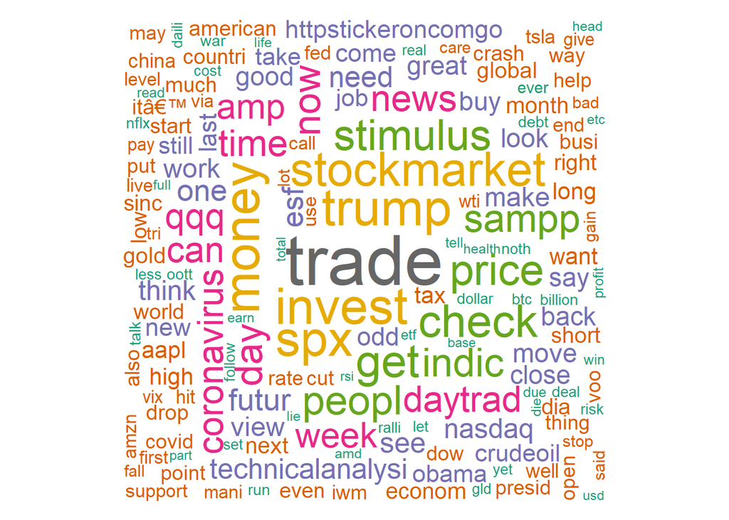

### Performing sentiment analysis

Sentiment analysis is a type of data mining that measures the inclination of people’s opinions through natural language processing (NLP), computational linguistics and text analysis, which are used to extract and analyze subjective information from Social Media or other mediums such as text documents. In this case we are using it to analyze the sentiments of the tweets we collected. In the figure below we created a barplot of the sentiment of the tweets brokendown in columns these include one for each emotion type as well as a positive or negative valence. The ten columns are as follows: “anger”, “anticipation”, “disgust”, “fear”, “joy”, “sadness”, “surprise”, “trust”, “negative”, “positive.”

The most prevalent emotion seemed to be trust, and the most common sentiment seemed to be negative. The emotions seemed to be reasonably balanced, most probably due to the market being at an almost all-time high at the beginning of the year and then going on a very steep decline towards the second half of our data. This leads to to belive there is a correlation between the market and our twitter data.

Sentiment BarPlot:

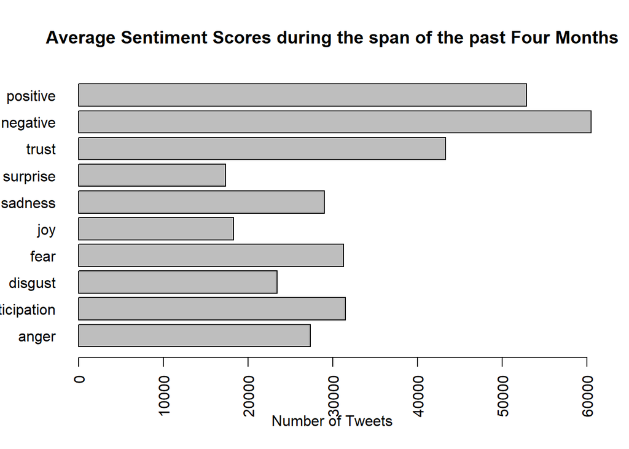

### Unsmoothed Stock Market Performance

The graph below is a time series of the performance of the S&P 500 Index, our metric for market performance during the past four months. We can see that the market behaved in a reasonably consistent manner during January and February. However, as the COVID-19 pandemic erupted near the end of February, coronavirus cases rapidly increased, and unemployment numbers rose; the market took a very sharp hit and went down to its lowest point in the last two months. We can see an increase again, most probably due to the talks of stimulus packages and increased testing across the United States.

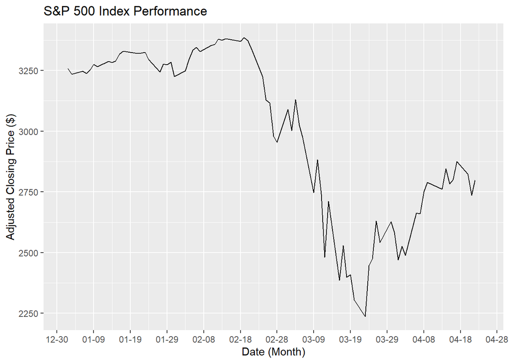

### Smoothed Stock Market Performance

To be able to better understand the trend we applied a smoothing parameter to the graph. Here’s the output.

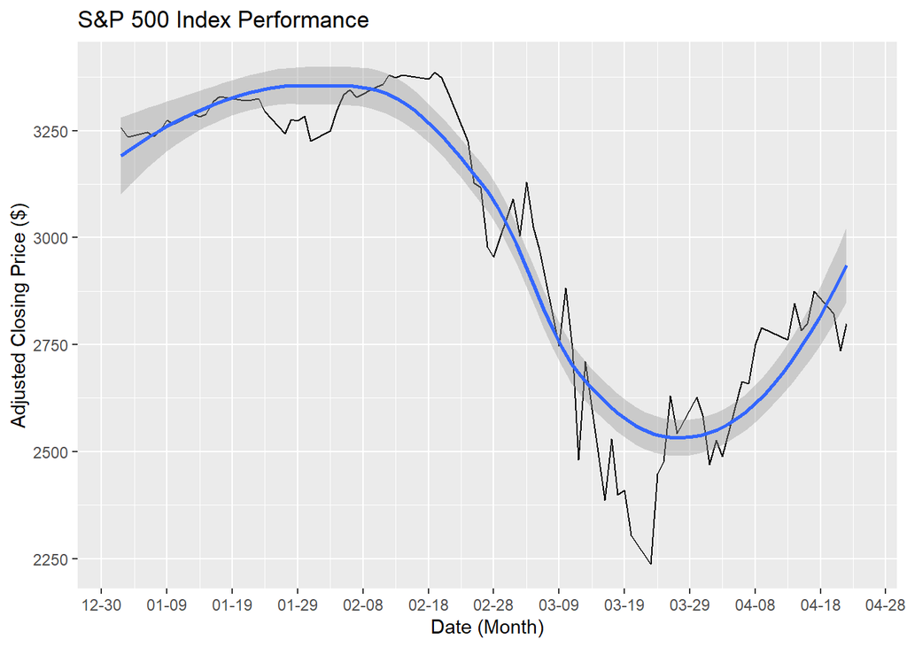

### Market Performance vs Sentiment Analysis

To better observe if market performance was in line with the sentiment corresponding to the same date, we calculated the mean sentiment of every day of tweets using sentiment analysis. We plotted the results in a time series and displayed it next to the stock’s performance and making the dates line up (Figure Below). What we observed when we did this is that, in fact, the sentiments correlated with the market performance. We also saw that twitter is reacting to current events. We can extrapolate this because the significant changes in sentiment seem to happen a day after a significant difference in the stock market performance.

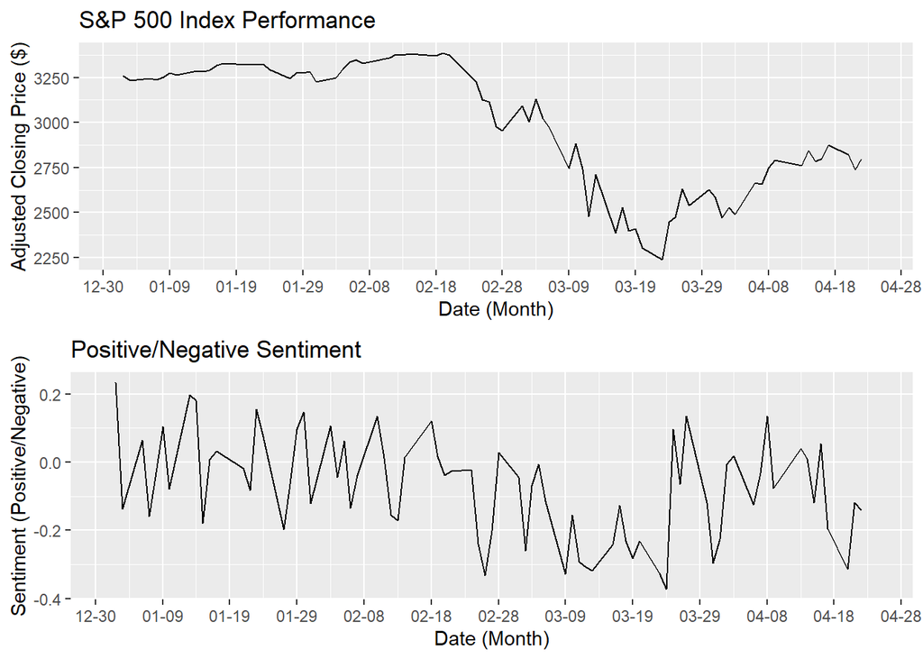

#### Smoothed Version

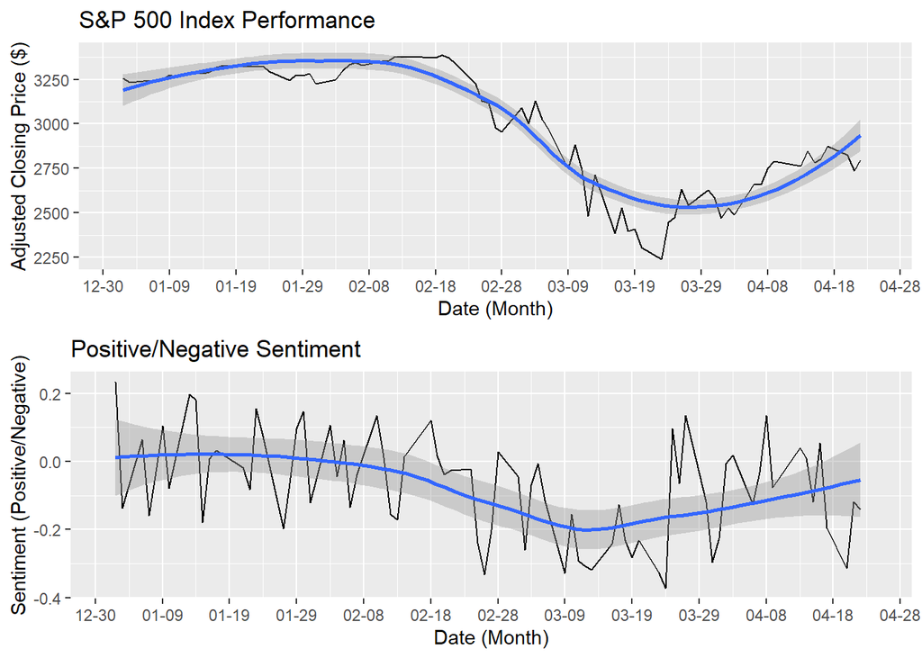

### Scatter Plot

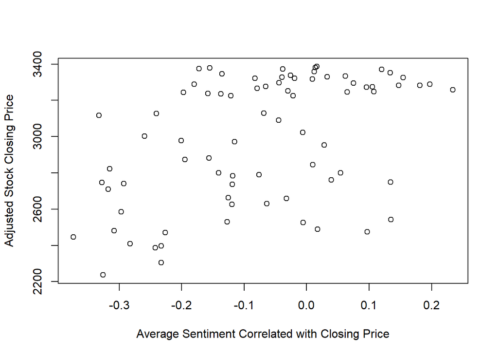

### Correlation between Average Sentiment and Adjusted Closing Price

We calculated the correlation between average sentiment and adjusted closing price using Pearson correlation, which measures a linear dependence between two variables (x and y). It’s also known as a parametric correlation test because it depends on the distribution of the data. The equation is the following $r = \frac{\sum{(x-m_x)(y-m_y)}}{\sqrt{\sum{(x-m_x)^2}\sum{(y-m_y)^2}}}$

After Running the correlation test we can see from our low P-Value of 1.811e-05 and our correlation of 0.46 that there’s a moderate postive, moderate correlation between the stock closing price and the twitter sentiment of that day. As sentiment market closing price increases so does the mean sentiment value.

####Correlation Output

```
##
##  Pearson's product-moment correlation
##
## data:  average.df$average_sents and stocks$Adj.Close
## t = 4.5804, df = 75, p-value = 1.811e-05
## alternative hypothesis: true correlation is not equal to 0
## 95 percent confidence interval:
##  0.2720387 0.6259607
## sample estimates:
##       cor
## 0.4675305
```

### Creating a linear model

A linear regression model is a model that assumes a linear relationship between the input variables (x) and the single output variable (y) Example: $Y = B0 + B1*x$.

Our linear model is summed up in the following equation $Closing Price = a(Intercept) + Avg Sentiment of Day × b1$. So if we were to assume that in a random day the Avgerage sentiment is -.30, we would expect the closing price to be on average around 2746.538. The equation would look the follwing way $3070.67 + (1080.44 + -0.30) = 2746.53$. If we look at our R-Squared Value of 0.20, this means our model can account for 20 percent of the variance exhibited in the data. This is not exceptional but acceptable in our view due to the fact that we only have a single predictor variable in an extremely unpredictable market segment.

```
##
## Call:
## lm(formula = stocks$Adj.Close ~ average.df$average_sents)
##
## Residuals:
##     Min      1Q  Median      3Q     Max
## -699.98 -234.97   61.91  274.09  489.37
##
## Coefficients:
##                          Estimate Std. Error t value Pr(>|t|)
## (Intercept)               3070.67      39.07   78.59  < 2e-16 ***
## average.df$average_sents  1080.44     235.89    4.58 1.81e-05 ***
## ---
## Signif. codes:  0 '***' 0.001 '**' 0.01 '*' 0.05 '.' 0.1 ' ' 1
##
## Residual standard error: 306.1 on 75 degrees of freedom
## Multiple R-squared:  0.2186, Adjusted R-squared:  0.2082
## F-statistic: 20.98 on 1 and 75 DF,  p-value: 1.811e-05
```

### Attempting to Predict the Market with Twitter Data

After we assessed the correlation between the S&P 500 Index and Twitter sentiment, we used the data to try to predict the index price. To make these predictions, we utilized our linear model and the sentiments exhibited during the tweets in April to obtain the predicted index closing price at each corresponding market day.We created a testing data set, which includes a subset of the data containing the mean sentiments and adjusted closing prices from the month of March, and we ran it against a testing set ,which was a subset of our data containing the sentiments of April.

#### Graphed prediction side by side with Index Performance.

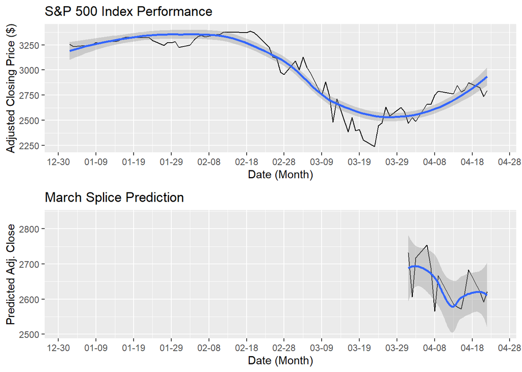

### Model Performance

After analyzing the model, we came to the following conclusions. From our obtained R-Squared Value, our model can only account for 5 percent of the variance and has a P-Value of 0.152, meaning our findings are not very accurate. This can be attributed to the extremely volatile market we have seen during the past two months. We observe the market shapely rising in April while it was crashing in march. This and the fact that we are only using one variable as a predictor could explain the lack of accuracy in our model.

```
##
## Call:
## lm(formula = stocks$Adj.Close[c(41:62)] ~ average.df$average_sents[c(41:62)])
##
## Residuals:
##     Min      1Q  Median      3Q     Max
## -339.30 -213.33  -75.85  207.00  412.27
##
## Coefficients:
##                                    Estimate Std. Error t value Pr(>|t|)
## (Intercept)                         2757.94      89.75  30.731   <2e-16 ***
## average.df$average_sents[c(41:62)]   586.38     393.85   1.489    0.152
## ---
## Signif. codes:  0 '***' 0.001 '**' 0.01 '*' 0.05 '.' 0.1 ' ' 1
##
## Residual standard error: 258.1 on 20 degrees of freedom
## Multiple R-squared:  0.09977,    Adjusted R-squared:  0.05476
## F-statistic: 2.217 on 1 and 20 DF,  p-value: 0.1521
```